# STT 301 Homework Assignment 3

Rellika Kisyula

10/26/2018

```r
knitr::opts_chunk$set(warning=FALSE, message=TRUE, comment = NA)
```

# Question 1 (6 points)

The `tb_cases.csv` file (available on D2L - Data Sets section) contains tuberculosis (TB) cases by country, year, age, gender, and diagnosis method. The data is from 1980 to 2013. A data dictionary is available at http://www.who.int/tb/country/data/download/en/ (http://www.who.int/tb/country/data/download/en/).

The objective in question 1 is to make the data tidy. Each of the subsequent parts will help you in the process of tidying the data. The resulting tibble is shown (by default only 10 rows) for most of the parts. You must use the functions in the `tidyr` package and `dplyr` package (both of which are loaded when you load the `tidyverse` package) along with the pipe operator (where applicable) to earn full credit. You will also need to load the `stringr` package.

You should think about why you are doing what you are doing and how it is a step in the process to tidy data. This may be a large component of your project, so it is imperative to have a good understanding of what is going on and why it is being done.

## Part a (0.25 points)

Read in the `tb_cases.csv` file and save it as an object named `tb.cases`. Convert `tb.cases` to a tibble using `as_tibble` and save it as `tb.cases`. The result should be as below.

```r
# Load in the required packages
library(tidyverse)
library(stringr)
```

```r
tb.cases <- read.csv("tb_cases.csv", header = TRUE, stringsAsFactors = FALSE)
tb.cases <- as.tibble(tb.cases)
tb.cases
```

```
# A tibble: 7,240 x 60
   country iso2  iso3   year new_sp_m014 new_sp_m1524 new_sp_m2534
   <chr>   <chr> <chr> <int>       <int>        <int>        <int>
 1 Afghan… AF    AFG    2013          NA           NA           NA
 2 Albania AL    ALB    2013          NA           NA           NA
 3 Algeria DZ    DZA    2013          NA           NA           NA
 4 Americ… AS    ASM    2013          NA           NA           NA
 5 Andorra AD    AND    2013          NA           NA           NA
 6 Angola  AO    AGO    2013          NA           NA           NA
 7 Anguil… AI    AIA    2013          NA           NA           NA
 8 Antigu… AG    ATG    2013          NA           NA           NA
 9 Argent… AR    ARG    2013          NA           NA           NA
10 Armenia AM    ARM    2013          NA           NA           NA
# ... with 7,230 more rows, and 53 more variables: new_sp_m3544 <int>,
#   new_sp_m4554 <int>, new_sp_m5564 <int>, new_sp_m65 <int>,
#   new_sp_f014 <int>, new_sp_f1524 <int>, new_sp_f2534 <int>,
#   new_sp_f3544 <int>, new_sp_f4554 <int>, new_sp_f5564 <int>,
#   new_sp_f65 <int>, new_sn_m014 <int>, new_sn_m1524 <int>,
#   new_sn_m2534 <int>, new_sn_m3544 <int>, new_sn_m4554 <int>,
#   new_sn_m5564 <int>, new_sn_m65 <int>, new_sn_f014 <int>,
#   new_sn_f1524 <int>, new_sn_f2534 <int>, new_sn_f3544 <int>,
#   new_sn_f4554 <int>, new_sn_f5564 <int>, new_sn_f65 <int>,
#   new_ep_m014 <int>, new_ep_m1524 <int>, new_ep_m2534 <int>,
#   new_ep_m3544 <int>, new_ep_m4554 <int>, new_ep_m5564 <int>,
#   new_ep_m65 <int>, new_ep_f014 <int>, new_ep_f1524 <int>,
#   new_ep_f2534 <int>, new_ep_f3544 <int>, new_ep_f4554 <int>,
#   new_ep_f5564 <int>, new_ep_f65 <int>, newrel_m014 <int>,
#   newrel_m1524 <int>, newrel_m2534 <int>, newrel_m3544 <int>,
#   newrel_m4554 <int>, newrel_m5564 <int>, newrel_m65 <int>,
#   newrel_f014 <int>, newrel_f1524 <int>, newrel_f2534 <int>,
#   newrel_f3544 <int>, newrel_f4554 <int>, newrel_f5564 <int>,
#   newrel_f65 <int>
```

## Part b (1 point)

Modify `tb.cases` to get the result you see below. Save the new tibble as `tb.cases1`. If you get a tibble with 405,440 rows it is because you did not remove the NA values. The below tibble is enough to note all the changes that were made.

```r
tb.cases1 <- gather(tb.cases, key = "diag", value = "cases", -c(1:4), na.rm = T)
tb.cases1
```

```
# A tibble: 76,046 x 6
   country             iso2  iso3   year diag        cases
 * <chr>               <chr> <chr> <int> <chr>       <int>
 1 Afghanistan         AF    AFG    2012 new_sp_m014   188
 2 Albania             AL    ALB    2012 new_sp_m014     0
 3 Algeria             DZ    DZA    2012 new_sp_m014    29
 4 Andorra             AD    AND    2012 new_sp_m014     0
 5 Angola              AO    AGO    2012 new_sp_m014   390
 6 Anguilla            AI    AIA    2012 new_sp_m014     0
 7 Antigua and Barbuda AG    ATG    2012 new_sp_m014     0
 8 Argentina           AR    ARG    2012 new_sp_m014    59
 9 Armenia             AM    ARM    2012 new_sp_m014     1
10 Australia           AU    AUS    2012 new_sp_m014     3
# ... with 76,036 more rows
```

## Part c (1 point)

A note on the diag variable from tb.cases1.

1. The first three letters denote whether it is a new or old case of TB. In this data set all are new cases of TB.
2. The next two letters after new describe the type of TB. `rel` stands for relapse cases `ep` stands for extrapulmonary TB cases `sn` stands for pulmonary TB cases that could not be diagnosed by a pulmonary smear `sp` stands for pulmonary TB cases that could be diagnosed by a pulmonary smear
3. The subsequent letter gives the gender ( `m` or `f` ).
4. The numbers that conclude the string signify an age group. 014 = 0-14 years old 1524 = 15-24 years old 2534 = 25-34 years old 3544 = 35-44 years old 4554 = 45-54 years old 5564 = 55-64 years old 65 = 65 or older

Look at a table of the `diag` variable from `tb.cases1`. You will notice that we have an inconsistency with regards to the values of this variable: `newrel` instead of `new_rel`. We will fix this so all values of the variable start with `new_rel`. To do this, use the mutate function (over-write the diag variable) along with `str_replace(diag, "newrel", "new_rel")`. Modify `tb.cases1` to get the result you see below. Save the new tibble as `tb.cases2`. You can look at a table of the `diag` variable from your new tibble to see if the change was made correctly.

```r
tb.cases2 <- mutate(tb.cases1, diag = str_replace(diag, "newrel", "new_rel"))
head(tb.cases2)
```

```
# A tibble: 6 x 6
  country     iso2  iso3   year diag        cases
  <chr>       <chr> <chr> <int> <chr>       <int>
1 Afghanistan AF    AFG    2012 new_sp_m014   188
2 Albania     AL    ALB    2012 new_sp_m014     0
3 Algeria     DZ    DZA    2012 new_sp_m014    29
4 Andorra     AD    AND    2012 new_sp_m014     0
5 Angola      AO    AGO    2012 new_sp_m014   390
6 Anguilla    AI    AIA    2012 new_sp_m014     0
```

## Part d (1 point)

Modify `tb.cases2` to get the result you see below. Save the new tibble as `tb.cases3`. The below tibble is enough to note all the changes that were made.

```r
tb.cases3 <- separate(data = tb.cases2, col = diag, into = c("new", "type", "sex.age"), sep="_")
tb.cases3
```

```
# A tibble: 76,046 x 8
   country             iso2  iso3   year new   type  sex.age cases
   <chr>               <chr> <chr> <int> <chr> <chr> <chr>   <int>
 1 Afghanistan         AF    AFG    2012 new   sp    m014      188
 2 Albania             AL    ALB    2012 new   sp    m014        0
 3 Algeria             DZ    DZA    2012 new   sp    m014       29
 4 Andorra             AD    AND    2012 new   sp    m014        0
 5 Angola              AO    AGO    2012 new   sp    m014      390
 6 Anguilla            AI    AIA    2012 new   sp    m014        0
 7 Antigua and Barbuda AG    ATG    2012 new   sp    m014        0
 8 Argentina           AR    ARG    2012 new   sp    m014       59
 9 Armenia             AM    ARM    2012 new   sp    m014        1
10 Australia           AU    AUS    2012 new   sp    m014        3
# ... with 76,036 more rows
```

## Part e (1 point)

Modify `tb.cases3` to get the result you see below. Save the new tibble as `tb.cases4`. The below tibble is enough to note all the changes that were made.

```r
tb.cases4 <- tb.cases3 %>% select (-c(iso2, iso3, new))
tb.cases4
```

```
# A tibble: 76,046 x 5
   country              year type  sex.age cases
   <chr>               <int> <chr> <chr>   <int>
 1 Afghanistan          2012 sp    m014      188
 2 Albania              2012 sp    m014        0
 3 Algeria              2012 sp    m014       29
 4 Andorra              2012 sp    m014        0
 5 Angola               2012 sp    m014      390
 6 Anguilla             2012 sp    m014        0
 7 Antigua and Barbuda  2012 sp    m014        0
 8 Argentina            2012 sp    m014       59
 9 Armenia              2012 sp    m014        1
10 Australia            2012 sp    m014        3
# ... with 76,036 more rows
```

## Part f (1 point)

Modify `tb.cases4` to get the result you see below. Save the new tibble as `tb.cases5`. The below tibble is enough to note all the changes that were made.

```r
tb.cases5 <- separate(data = tb.cases4, col = sex.age, into = c("sex", "age"), sep=1)
tb.cases5
```

```
# A tibble: 76,046 x 6
   country              year type  sex   age   cases
   <chr>               <int> <chr> <chr> <chr> <int>
 1 Afghanistan          2012 sp    m     014     188
 2 Albania              2012 sp    m     014       0
 3 Algeria              2012 sp    m     014      29
 4 Andorra              2012 sp    m     014       0
 5 Angola               2012 sp    m     014     390
 6 Anguilla             2012 sp    m     014       0
 7 Antigua and Barbuda  2012 sp    m     014       0
 8 Argentina            2012 sp    m     014      59
 9 Armenia              2012 sp    m     014       1
10 Australia            2012 sp    m     014       3
# ... with 76,036 more rows
```

## Part g (0.25 points)

Modify `tb.cases5` to get the result you see below. Save the new tibble as `tb.cases6`. The below tibble is enough to note all the changes that were made.

```r
tb.cases6 <- tb.cases5 %>% select(country, year, age, sex, type, cases)
tb.cases6
```

```
# A tibble: 76,046 x 6
   country              year age   sex   type  cases
   <chr>               <int> <chr> <chr> <chr> <int>
 1 Afghanistan          2012 014   m     sp      188
 2 Albania              2012 014   m     sp        0
 3 Algeria              2012 014   m     sp       29
 4 Andorra              2012 014   m     sp        0
 5 Angola               2012 014   m     sp      390
 6 Anguilla             2012 014   m     sp        0
 7 Antigua and Barbuda  2012 014   m     sp        0
 8 Argentina            2012 014   m     sp       59
 9 Armenia              2012 014   m     sp        1
10 Australia            2012 014   m     sp        3
# ... with 76,036 more rows
```

# Part h (0.50 points)

Use one of the apply family of functions to change each of the character variables to a factor. The tibble should remain named `tb.cases6`. The result is below.

```r
tb.cases6[] <-lapply(tb.cases6 , function(x) if(is.character(x)) as.factor(x) else x)
tb.cases6
```

```
# A tibble: 76,046 x 6
   country              year age   sex   type  cases
   <fct>               <int> <fct> <fct> <fct> <int>
 1 Afghanistan          2012 014   m     sp      188
 2 Albania              2012 014   m     sp        0
 3 Algeria              2012 014   m     sp       29
 4 Andorra              2012 014   m     sp        0
 5 Angola               2012 014   m     sp      390
 6 Anguilla             2012 014   m     sp        0
 7 Antigua and Barbuda  2012 014   m     sp        0
 8 Argentina            2012 014   m     sp       59
 9 Armenia              2012 014   m     sp        1
10 Australia            2012 014   m     sp        3
# ... with 76,036 more rows
```

# Question 2 (2 points)

## Part a (0.50 points)

Create a tibble showing the total number of cases of TB for each age group and gender.

```r
tb.total <- tb.cases6 %>% group_by(age, sex) %>% summarize(totalNumber = sum(cases))
tb.total
```

```
# A tibble: 14 x 3
# Groups:   age [?]
   age   sex   totalNumber
   <fct> <fct>       <int>
 1 014   f          884247
 2 014   m          824004
 3 1524  f         3421560
 4 1524  m         4221167
 5 2534  f         3870651
 6 2534  m         5765476
 7 3544  f         3018113
 8 3544  m         5748603
 9 4554  f         1960221
10 4554  m         4540505
11 5564  f         1409548
12 5564  m         3390120
13 65    f         1342684
14 65    m         3000619
```

## Part b (0.50 points)

In what country and year were TB cases highest?

```r
tb.cases6 %>% arrange(desc(cases))
```

```
# A tibble: 76,046 x 6
   country  year age   sex   type   cases
   <fct>   <int> <fct> <fct> <fct>  <int>
 1 India    2007 3544  m     sn    250051
 2 India    2007 3544  f     sn    148811
 3 China    2013 65    m     rel   124476
 4 China    2013 5564  m     rel   112558
 5 India    2007 3544  m     ep    105825
 6 India    2007 3544  f     ep    101015
 7 China    2013 4554  m     rel   100297
 8 India    2009 3544  m     sp     90830
 9 India    2008 3544  m     sp     90498
10 India    2010 3544  m     sp     90440
# ... with 76,036 more rows
```

**Sol** `the cases were highest in 2007 in India`

## Part c (0.50 points)

Create a tibble that shows the total number of TB cases for each year and diagnosis type, but only for years after 2009

```r
sol.tb.cases <- tb.cases6 %>% filter(year > 2009) %>% select(year, type, cases) %>% group_by(year, type) %>% summarize(totalNumber = sum(cases))

sol.tb.cases
```

```
# A tibble: 10 x 3
# Groups:   year [?]
    year type  totalNumber
   <int> <fct>       <int>
 1  2010 ep         293861
 2  2010 sn        1097878
 3  2010 sp        2595072
 4  2011 ep         286035
 5  2011 sn        1099655
 6  2011 sp        2591461
 7  2012 ep         300661
 8  2012 sn        1186575
 9  2012 sp        2475353
10  2013 rel       3220572
```

## Part d (0.50 points)

Give code to produce the tibble you see below

```r
tb.countries <- tb.cases6 %>%
    filter(country %in% c("Brazil", "China", "India", "Indonesia", "United States of America") & year > 2007) %>%
    arrange(country, year) %>%
    group_by(country, year) %>%
    summarize(total.cases = sum(cases),
              avg.per.month =round (total.cases/12, digits = 0))
tb.countries  %>% print(n=30)
```

```
# A tibble: 29 x 4
# Groups:   country [?]
   country                   year total.cases avg.per.month
   <fct>                    <int>       <int>         <dbl>
 1 Brazil                    2008       70484          5874
 2 Brazil                    2009       71572          5964
 3 Brazil                    2010       70848          5904
 4 Brazil                    2011       71202          5934
 5 Brazil                    2012       71072          5923
 6 Brazil                    2013       75996          6333
 7 China                     2008      462596         38550
 8 China                     2009      884477         73706
 9 China                     2010      869092         72424
10 China                     2011      865059         72088
11 China                     2012      858861         71572
```

[output cut: 18 more lines]

# Question 3 (2 points)

Use `ggplot`, or similar packages in the grammar of graphics, to create at least `three distinct` and informative visualizations of the `tb.cases6` tibble. The plots should be descriptive and well labeled as if you were using these in a presentation or paper.

Furthermore, you should pose at least one question you would be interested in further investigating based off the plots and your data analysis. The questions need not be answered. It is also okay if the questions you raise are unable to be answered based off the scope of the data. For example: “Does less government spending result in more relapse TB cases?”.

```r
usa <- tb.cases6 %>% filter(country =="United States of America") %>% group_by(year, age, sex, type) %>% summarise(total.cases = sum(cases))

usa
```

```
# A tibble: 462 x 5
# Groups:   year, age, sex [?]
    year age   sex   type  total.cases
   <int> <fct> <fct> <fct>       <int>
 1  1995 014   f     sp             26
 2  1995 014   m     sp             19
 3  1995 1524  f     sp            280
 4  1995 1524  m     sp            355
 5  1995 2534  f     sp            579
 6  1995 2534  m     sp            876
 7  1995 3544  f     sp            499
 8  1995 3544  m     sp           1417
 9  1995 4554  f     sp            285
10  1995 4554  m     sp           1121
# ... with 452 more rows
```

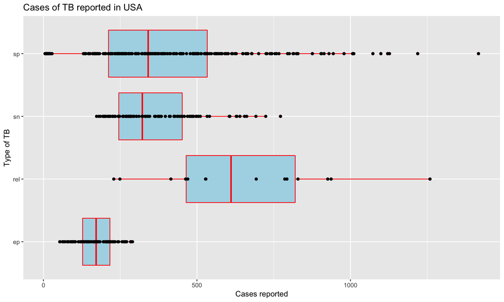

```r
gg <- ggplot(data = usa,
    aes(x = type, y = total.cases)) +
    geom_boxplot(color = "red", fill = "lightblue") +
    labs(title = "Cases of TB reported in USA",
         x = "Type of TB",
         y = "Cases reported") +
    geom_point(aes(y=total.cases), position = position_dodge(width=0.75)) + coord_flip()
gg
```